# Missing indicator method

J. Hoogland, K.G.M. Moons

November 2020

## Introduction

The missing data methods that have been discussed in the lectures thus far either ignore (delete) records with missing data on the determinants (independent variables/co-variates/predictors/confounders) or outcomes (dependent variables), such as complete case or available case analysis, or impute missing determinants’ or outcome data. Imputation of missing data is by far the most popular way of handling missing data problems, and the more advanced imputation methods - that will be introduced in the next lectures and exercises - are most widely advocated. However, there is another method for handling missing determinant data in medical research, that does not impute data but still allows one to use all study records: the so-called missing indicator method. Note this method is not for dealing with missing outcome data.

## The missing indicator method

With the missing indicator method, missing observations on a particular independent variable are set to some fixed (but arbitrary) value. For instance, consider an observational study where the interest is in estimating the effect of age on bone mineral density (BMD) after 6 months, and smoking, sex and (the inverse of) vitamin D level (vitD) are known confounders. Now we observe missing observations for one of the confounders (VitD), for some % of the study participants. One sets all missing vitD values to, e.g., a value of 0 (or some other randomly chosen value). Additionally, a so-called missing indicator variable for VitD is added (hence the name of the method), which indicates whether that independent variable measurement (vitD) was originally missing (1) or observed (0). Thus, the first 10 rows of the data looked like

```
##            bmd      age smoking sex       vitD
## 1  -0.95174931 62.46156       0   1         NA
## 2   0.20412772 56.61876       0   0         NA
## 3  -0.37874193 72.98637       1   1         NA
## 4  -0.40230149 49.81486       0   1 0.02362124
## 5  -1.88348449 69.69362       0   1         NA
## 6   0.89494757 54.83268       0   0 0.02971135
## 7   1.13483962 68.81802       0   0         NA
## 8  -3.51214720 81.29323       0   0 0.08183295
## 9  -1.70155882 59.22265       0   1 0.02331066
## 10 -0.03347997 76.52173       0   1 0.03120595
```

and become after the introduction of the missing indicator for VitD:

```
##            bmd      age smoking sex       vitD indicator
## 1  -0.95174931 62.46156       0   1 0.00000000         1
## 2   0.20412772 56.61876       0   0 0.00000000         1
## 3  -0.37874193 72.98637       1   1 0.00000000         1
## 4  -0.40230149 49.81486       0   1 0.02362124         0
## 5  -1.88348449 69.69362       0   1 0.00000000         1
## 6   0.89494757 54.83268       0   0 0.02971135         0
## 7   1.13483962 68.81802       0   0 0.00000000         1
## 8  -3.51214720 81.29323       0   0 0.08183295         0
## 9  -1.70155882 59.22265       0   1 0.02331066         0
## 10 -0.03347997 76.52173       0   1 0.03120595         0
```

Before using the indicator method, a linear regression model regressing bmd on the determinants and confounders could be written as:

$$BMD_i = \beta_0 + \beta_1* age_i + \beta_2 * smoking_i + \beta_3 * sex_i + \beta_4 * vitD_i + \epsilon_i$$
Note that if this model would be fitted all individuals with a missing VitD observations would be simply deleted (so-called complete case analysis). And if missingness was nót MCAR, then we would observe biased estimates of all regression parameters: $\beta_0$, $\beta_1$, $\beta_2$, $\beta_3$ and $\beta_4$.

Now, after using the indicator method, the linear regression model regressing bmd on the determinants and including the indicator variable, can be written as:

$$BMD_i = \beta_0 + \beta_1* age_i + \beta_2 * smoking_i + \beta_3 * sex_i + \beta_4 * vitD_i + \beta_5 * indicator_i + \epsilon_i$$
Note that we in fact have two slightly different regession models: for the individuals with originally missing VitD and for the individuals with observed VitD. For participants with observed vitD, the indicator variable is always zero and therefore $\beta_5$ can be ignored, such that the applicable model for these participants is:

$$BMD_i = \beta_0 + \beta_1* age_i + \beta_2 * smoking_i + \beta_3 * sex_i + \beta_4 * vitD_i + \epsilon_i \quad \quad (a)$$
Note that these participants in fact form the complete cases. The resulting β estimates will only be unbiased when the vitD data were missing completely at random.

Now think about the participants with missing vitD. For them the following parts of the model apply (note that here the indicator variable is always equal to 1 and that we replaced the missing vitD values with 0 – so $\beta_4$*0 = 0)

$$BMD_i = \beta_0 + \beta_1* age_i + \beta_2 * smoking_i + \beta_3 * sex_i + \beta_5 + \epsilon_i\quad \quad (b)$$
The regression model estimates for the individuals with missing VitD, are then thus *not adjusted for vitD levels* and are therefore only unbiased if a) vitD level is not correlated to the other determinants and b) missingness of vitD level is not related to the outcome conditional on the other determinants.

The final results based on the missing indicator method will therefore be some weighted average between the associations (a) and (b) as studied in complete and incomplete cases respectively. This is exactly what was observed by Groenwold et al. (2012; doi:10.1503/cmaj.110977) in a very nice overview on the missing indicator method: “When using the missing-indicator method to adjust for an incomplete covariate, the estimated association between the independent variable under study (e.g., treatment, risk factor or predictor) and outcome is a weighted average of two associations representing (a) the association between the independent variable and outcome, adjusted for all covariates, among the participants for whom all data were observed; and (b) the association between the independent variable and outcome, adjusted only for complete covariates (or confounders), among the participants for whom the covariate (or confounder) was not observed.”

The results based on the missing indicator method can therefore be understood as a weighted average of a complete case analysis on one part of the data (a), and an analysis in which an important confounder is dropped on the other part of the data (b). This observation gives insight into the settings in which the missing indicator will and will not work. The (a) part is only unbiased under MCAR missing data and the (b) part is usually biased since part of the confounder information is missing and the therefore unadjusted. Note that the bias of part (b) also occurs under MCAR missing data, so the overall result, which is based on (a) *and* (b) will still be biased.

Therefore, the missing indicator method will generally provide biased estimates of the associaitons under study. This applies to all types of applied medical research, including etiologic, prognostic, diagnostic and also observational therapeutic research. There is one setting where the MIM does give unbiased estimates of the association under study: estimation of the treatment effect in a randomized trial with missing baseline measurements. In that case, the differences in baseline characteristics and their missingness between treatment groups are typically completely random, and the baseline characteristics are not related to treatment due to the randomisation. We will return to this in the exercises.

## Computer practical

For this computer practical, you need to have access to the free software [R](https://www.r-project.org/) and [RStudio](https://www.rstudio.com/products/rstudio/) (desktop edition). Make sure you install `R` first. Although it is not necessary to have any experience in `R` programming for this practical, a tutorial is available [online](http://tryr.codeschool.com/).

Alternatively, you can use RStudio in the cloud, which only requires access to an internet browser such as Google Chrome. RStudio Cloud is currently free to use. Please visit https://rstudio.cloud/ and choose “Get Started”.

This practical was developed using R version 4.0.2. Open RStudio and verify if your installed version is up-to-date:

```r
R.Version()$version.string
```

For this practical, the R version used is not critical.

Let’s first load the observational data

```r
load("obs_data_complete.RData") # compete data set
load("obs_data_miss.RData") # data with missing vitamin D data
```

and take a look at the firs cases

```r
head(obs.data.complete)
head(obs.data.miss)
```

### Etiologic research

The outcome of interest is bone mineral density (bmd) and bmd is known to be affected by age, smoking, sex and vitamin D (among others) – potential confounders. Consider the question whether age is an etiolofic risk factor of BMD where we need to adjust for smoking, sex and VitD.

**Question 1.** How many observations do we have? What percentage of the vitamin D data is missing?

```r
nrow(obs.data.miss) # number of cases
```

```
## [1] 5000
```

```r
mean(is.na(obs.data.miss$vitD)) * 100 # % of missing vitD data
```

```
## [1] 40.66
```

Let’s say we’re interested in the effect of age on bmd after adjusting for smoking, sex, and vitamin D level.

**Question 2.** How could you verify that vitD is indeed a confounder? You may use the complete data set.

```r
summary(lm(bmd ~ age + smoking + sex + vitD, data=obs.data.complete))
```

```
##
## Call:
## lm(formula = bmd ~ age + smoking + sex + vitD, data = obs.data.complete)
##
## Residuals:
##     Min      1Q  Median      3Q     Max
## -3.2655 -0.6857  0.0048  0.6803  3.2392
##
## Coefficients:
##              Estimate Std. Error t value Pr(>|t|)
## (Intercept)  5.034488   0.139185  36.171  < 2e-16 ***
## age         -0.079669   0.002803 -28.424  < 2e-16 ***
## smoking     -0.320795   0.033363  -9.615  < 2e-16 ***
## sex         -0.547146   0.031348 -17.454  < 2e-16 ***
## vitD        -5.882948   1.110470  -5.298 1.22e-07 ***
## ---
## Signif. codes:  0 '***' 0.001 '**' 0.01 '*' 0.05 '.' 0.1 ' ' 1
##
## Residual standard error: 0.9876 on 4995 degrees of freedom
## Multiple R-squared:  0.4526, Adjusted R-squared:  0.4521
## F-statistic:  1032 on 4 and 4995 DF,  p-value: < 2.2e-16
```

```r
summary(lm(bmd ~ age + smoking + sex, data=obs.data.complete))
```

```
##
## Call:
## lm(formula = bmd ~ age + smoking + sex, data = obs.data.complete)
##
## Residuals:
##     Min      1Q  Median      3Q     Max
## -3.2302 -0.6826  0.0020  0.6776  3.3104
##
## Coefficients:
##             Estimate Std. Error t value Pr(>|t|)
## (Intercept)  5.47327    0.11216  48.798   <2e-16 ***
## age         -0.09094    0.00183 -49.681   <2e-16 ***
## smoking     -0.26470    0.03172  -8.344   <2e-16 ***
## sex         -0.48969    0.02949 -16.605   <2e-16 ***
## ---
## Signif. codes:  0 '***' 0.001 '**' 0.01 '*' 0.05 '.' 0.1 ' ' 1
##
## Residual standard error: 0.9903 on 4996 degrees of freedom
## Multiple R-squared:  0.4495, Adjusted R-squared:  0.4492
## F-statistic:  1360 on 3 and 4996 DF,  p-value: < 2.2e-16
```

```r
# note that the estimated effect of age not adjusted for vitD is far off the the mark
# apparently, vitD is related to both age and the outcome after conditioning on the remaining variables
```

For the following question, consider it a given that the vitamin D data are Missing Completely At Random (MCAR).

**Question 3.** Would the complete case analysis (CCA) estimate of the age effect be biased? If you compare the CCA to an analysis on the complete data (so without missings), would the standard error of the age effect accoring to CCA be larger, equal, or smaller?

```r
summary(lm(bmd ~ age + smoking + sex + vitD, data=obs.data.complete))
```

```
##
## Call:
## lm(formula = bmd ~ age + smoking + sex + vitD, data = obs.data.complete)
##
## Residuals:
##     Min      1Q  Median      3Q     Max
## -3.2655 -0.6857  0.0048  0.6803  3.2392
##
## Coefficients:
##              Estimate Std. Error t value Pr(>|t|)
## (Intercept)  5.034488   0.139185  36.171  < 2e-16 ***
## age         -0.079669   0.002803 -28.424  < 2e-16 ***
## smoking     -0.320795   0.033363  -9.615  < 2e-16 ***
## sex         -0.547146   0.031348 -17.454  < 2e-16 ***
## vitD        -5.882948   1.110470  -5.298 1.22e-07 ***
## ---
## Signif. codes:  0 '***' 0.001 '**' 0.01 '*' 0.05 '.' 0.1 ' ' 1
##
## Residual standard error: 0.9876 on 4995 degrees of freedom
## Multiple R-squared:  0.4526, Adjusted R-squared:  0.4521
## F-statistic:  1032 on 4 and 4995 DF,  p-value: < 2.2e-16
```

```r
summary(lm(bmd ~ age + smoking + sex + vitD, data=obs.data.miss))
```

```
##
## Call:
## lm(formula = bmd ~ age + smoking + sex + vitD, data = obs.data.miss)
##
## Residuals:
##     Min      1Q  Median      3Q     Max
## -3.2511 -0.6832  0.0085  0.6750  3.2020
##
## Coefficients:
##              Estimate Std. Error t value Pr(>|t|)
## (Intercept)  4.865746   0.181923  26.746  < 2e-16 ***
## age         -0.076240   0.003666 -20.797  < 2e-16 ***
## smoking     -0.324485   0.044046  -7.367 2.25e-13 ***
## sex         -0.566055   0.041096 -13.774  < 2e-16 ***
## vitD        -7.108490   1.440170  -4.936 8.42e-07 ***
## ---
## Signif. codes:  0 '***' 0.001 '**' 0.01 '*' 0.05 '.' 0.1 ' ' 1
##
## Residual standard error: 0.9973 on 2962 degrees of freedom
##   (2033 observations deleted due to missingness)
## Multiple R-squared:  0.4484, Adjusted R-squared:  0.4476
## F-statistic: 601.9 on 4 and 2962 DF,  p-value: < 2.2e-16
```

```r
# The point estimates of the age effects are reasonably similar as they should be (the differences are random)
# the se is larger for the complete case analysis (as expected)
```

**Question 4.** Would, after applying the missing indicator method for VitD, the estimate of the age effect be biased? Use the missing indicator method to verify your answer. Doing so, check that the value inserted for missing vitD values is arbitrary.

To get started, the data can be prepared as follows

```r
obs.data.miss.ind <- obs.data.miss
obs.data.miss.ind$indicator <- ifelse(is.na(obs.data.miss$vitD), 1, 0)
obs.data.miss.ind$vitD <- ifelse(is.na(obs.data.miss$vitD), 0, obs.data.miss$vitD) # so we insert 0 for those with NA vitD
```

```r
summary(lm(bmd ~ age + smoking + sex + vitD, data=obs.data.complete))
```

```
##
## Call:
## lm(formula = bmd ~ age + smoking + sex + vitD, data = obs.data.complete)
##
## Residuals:
##     Min      1Q  Median      3Q     Max
## -3.2655 -0.6857  0.0048  0.6803  3.2392
##
## Coefficients:
##              Estimate Std. Error t value Pr(>|t|)
## (Intercept)  5.034488   0.139185  36.171  < 2e-16 ***
## age         -0.079669   0.002803 -28.424  < 2e-16 ***
## smoking     -0.320795   0.033363  -9.615  < 2e-16 ***
## sex         -0.547146   0.031348 -17.454  < 2e-16 ***
## vitD        -5.882948   1.110470  -5.298 1.22e-07 ***
## ---
## Signif. codes:  0 '***' 0.001 '**' 0.01 '*' 0.05 '.' 0.1 ' ' 1
##
## Residual standard error: 0.9876 on 4995 degrees of freedom
## Multiple R-squared:  0.4526, Adjusted R-squared:  0.4521
## F-statistic:  1032 on 4 and 4995 DF,  p-value: < 2.2e-16
```

```r
summary(lm(bmd ~ age + smoking + sex + vitD + indicator, data=obs.data.miss.ind))
```

```
##
## Call:
## lm(formula = bmd ~ age + smoking + sex + vitD + indicator, data = obs.data.miss.ind)
##
## Residuals:
##     Min      1Q  Median      3Q     Max
## -3.2686 -0.6894  0.0056  0.6768  3.2577
##
## Coefficients:
##              Estimate Std. Error t value Pr(>|t|)
## (Intercept)  5.342035   0.117371  45.514  < 2e-16 ***
## age         -0.086119   0.002258 -38.136  < 2e-16 ***
## smoking     -0.289764   0.032404  -8.942  < 2e-16 ***
## sex         -0.513473   0.030153 -17.029  < 2e-16 ***
## vitD        -4.170006   1.147541  -3.634 0.000282 ***
## indicator   -0.141376   0.054437  -2.597 0.009430 **
## ---
## Signif. codes:  0 '***' 0.001 '**' 0.01 '*' 0.05 '.' 0.1 ' ' 1
##
## Residual standard error: 0.9891 on 4994 degrees of freedom
## Multiple R-squared:  0.4511, Adjusted R-squared:  0.4505
## F-statistic: 820.7 on 5 and 4994 DF,  p-value: < 2.2e-16
```

```r
# The age estimate based on the missing indicator method is biased

obs.data.miss.ind$vitD <- ifelse(obs.data.miss.ind$indicator==1, 200, obs.data.miss$vitD) # insert (for instance) 200 instead of 0
summary(lm(bmd ~ age + smoking + sex + vitD, data=obs.data.complete))
```

```
##
## Call:
## lm(formula = bmd ~ age + smoking + sex + vitD, data = obs.data.complete)
##
## Residuals:
##     Min      1Q  Median      3Q     Max
## -3.2655 -0.6857  0.0048  0.6803  3.2392
##
## Coefficients:
##              Estimate Std. Error t value Pr(>|t|)
## (Intercept)  5.034488   0.139185  36.171  < 2e-16 ***
## age         -0.079669   0.002803 -28.424  < 2e-16 ***
## smoking     -0.320795   0.033363  -9.615  < 2e-16 ***
## sex         -0.547146   0.031348 -17.454  < 2e-16 ***
## vitD        -5.882948   1.110470  -5.298 1.22e-07 ***
## ---
## Signif. codes:  0 '***' 0.001 '**' 0.01 '*' 0.05 '.' 0.1 ' ' 1
##
## Residual standard error: 0.9876 on 4995 degrees of freedom
## Multiple R-squared:  0.4526, Adjusted R-squared:  0.4521
## F-statistic:  1032 on 4 and 4995 DF,  p-value: < 2.2e-16
```

```r
summary(lm(bmd ~ age + smoking + sex + vitD + indicator, data=obs.data.miss.ind))
```

```
##
## Call:
## lm(formula = bmd ~ age + smoking + sex + vitD + indicator, data = obs.data.miss.ind)
##
## Residuals:
##     Min      1Q  Median      3Q     Max
## -3.2686 -0.6894  0.0056  0.6768  3.2577
##
## Coefficients:
##               Estimate Std. Error t value Pr(>|t|)
## (Intercept)   5.342035   0.117371  45.514  < 2e-16 ***
## age          -0.086119   0.002258 -38.136  < 2e-16 ***
## smoking      -0.289764   0.032404  -8.942  < 2e-16 ***
## sex          -0.513473   0.030153 -17.029  < 2e-16 ***
## vitD         -4.170006   1.147541  -3.634 0.000282 ***
## indicator   833.859830 229.461811   3.634 0.000282 ***
## ---
## Signif. codes:  0 '***' 0.001 '**' 0.01 '*' 0.05 '.' 0.1 ' ' 1
##
## Residual standard error: 0.9891 on 4994 degrees of freedom
## Multiple R-squared:  0.4511, Adjusted R-squared:  0.4505
## F-statistic: 820.7 on 5 and 4994 DF,  p-value: < 2.2e-16
```

```r
# same results, except of course for the effect of the indicator variable which needs to adjust to the new placeholder value
```

This example clearly shows that even while the missing VitD data are MCAR, the missing indicator method provides a biased estimate! Also, it gives a false impression of accuracy due to the low se (the effect of using all the data). Therefore, missing indicator results are even worse than a complete case analysis.

### Prediction Research (diagnostic or prognostic)

Up to now, we have focused on estimating the age effect, as etiologic . However, sometimes we are interested in developing a diagnostic or prognostic prediction model. In that case, *all* the $\beta$’s are of prime interest, *including* the intercept. Let us first fit the entire prediction model of interest on both the complete data (1) and on the missing data making use of the missing indicator method (2):

```r
#1
summary(lm(bmd ~ age + smoking + sex + vitD, data=obs.data.complete))
```

```
##
## Call:
## lm(formula = bmd ~ age + smoking + sex + vitD, data = obs.data.complete)
##
## Residuals:
##     Min      1Q  Median      3Q     Max
## -3.2655 -0.6857  0.0048  0.6803  3.2392
##
## Coefficients:
##              Estimate Std. Error t value Pr(>|t|)
## (Intercept)  5.034488   0.139185  36.171  < 2e-16 ***
## age         -0.079669   0.002803 -28.424  < 2e-16 ***
## smoking     -0.320795   0.033363  -9.615  < 2e-16 ***
## sex         -0.547146   0.031348 -17.454  < 2e-16 ***
## vitD        -5.882948   1.110470  -5.298 1.22e-07 ***
## ---
## Signif. codes:  0 '***' 0.001 '**' 0.01 '*' 0.05 '.' 0.1 ' ' 1
##
## Residual standard error: 0.9876 on 4995 degrees of freedom
## Multiple R-squared:  0.4526, Adjusted R-squared:  0.4521
## F-statistic:  1032 on 4 and 4995 DF,  p-value: < 2.2e-16
```

```r
#2
summary(lm(bmd ~ age + smoking + sex + vitD + indicator, data=obs.data.miss.ind))
```

```
##
## Call:
## lm(formula = bmd ~ age + smoking + sex + vitD + indicator, data = obs.data.miss.ind)
##
## Residuals:
##     Min      1Q  Median      3Q     Max
## -3.2686 -0.6894  0.0056  0.6768  3.2577
##
## Coefficients:
##               Estimate Std. Error t value Pr(>|t|)
## (Intercept)   5.342035   0.117371  45.514  < 2e-16 ***
## age          -0.086119   0.002258 -38.136  < 2e-16 ***
## smoking      -0.289764   0.032404  -8.942  < 2e-16 ***
## sex          -0.513473   0.030153 -17.029  < 2e-16 ***
## vitD         -4.170006   1.147541  -3.634 0.000282 ***
## indicator   833.859830 229.461811   3.634 0.000282 ***
## ---
## Signif. codes:  0 '***' 0.001 '**' 0.01 '*' 0.05 '.' 0.1 ' ' 1
##
## Residual standard error: 0.9891 on 4994 degrees of freedom
## Multiple R-squared:  0.4511, Adjusted R-squared:  0.4505
## F-statistic: 820.7 on 5 and 4994 DF,  p-value: < 2.2e-16
```

**Question 5.** What do you think of the $\beta$ estimates? Are they biased? Could we use them effectively in a prediction model?

```r
# Realize that the coefficients should correspond across models for patients with complete data (since then the indicator equals 0).
# This is evidently not the case, so all parameters are biased even under this MCAR scenario and the model is therefore not expected to perform well
```

**Question 6.** What do you think of the beta estimate and p-value of the effect of the indicator variable itself? What does this finding actually tell us and what does it mean when someone wants to use this model in new individuals to make BMD predictions?

```r
# Significance of the indicator variable essentially means that the intercept needs some adjustment for those with missing vitD data.
# In other words, the prevalence of the outcome is not the same among those with and without missing vitD data
# From a clinician's point of view, note that it is somewhat of a strange message that missing some of the data is predictive of the outcome.
# It may look as though it's useful not to measure something and this is clearly the wrong message and may even alter data collection. That is, it may
# alter the missing data mechanism and thereby invalidate the model!
```

### Randomised therapeutic trials

So far the missing indicator method did not perform well on any of the tasks we have examined thus far – and indeed is contraindicated to use.. Is there a *right* use of the MIM then? As already hinted to above, this is in the randomized trial setting that uses randomization on the variable (usually index treatment) of interest. To illustrate this, a treatment effect with coefficient 1 was added to the data used earlier. Let’s load the data first:

```r
load("rct_data_complete.RData") # compete data set
load("rct_data_miss.RData") # data with missing vitamin D data
```

**Question 7.** Due to randomization, which of the following methods should provide an unbiased estimate of the treatment effect: fully adjusted complete case analysis, fully adjusted missing indicator analysis (using the missing indicator method to account for baseline characteristic with missing observations), and totally unadjusted analysis?

```r
# The right answer is all of the above!
# The CC is unbiased due to MCAR missing data (but with larger se due to missing data)
# The unadjusted estimated is unbiased due to randomization (but with larger se due to omitting information on covariates that are related to the outcome)
# The missing indicator method is unbiased for the treatment effect estimate due to randomization, since # this leads to i) an unbiased CC part, and ii) an unbiased available case part of the weighted
# average described earlier
summary(lm(bmd ~ trt + age + smoking + sex + vitD, data=rct.data.complete))
```

```
##
## Call:
## lm(formula = bmd ~ trt + age + smoking + sex + vitD, data = rct.data.complete)
##
## Residuals:
##     Min      1Q  Median      3Q     Max
## -3.6783 -0.6878 -0.0141  0.6664  4.2255
##
## Coefficients:
##              Estimate Std. Error t value Pr(>|t|)
## (Intercept)  4.949238   0.158720  31.182  < 2e-16 ***
## trt          1.031367   0.031730  32.504  < 2e-16 ***
## age         -0.078565   0.003155 -24.900  < 2e-16 ***
## smoking     -0.301108   0.038074  -7.909 3.34e-15 ***
## sex         -0.516388   0.035584 -14.512  < 2e-16 ***
## vitD        -6.301307   1.250889  -5.037 4.93e-07 ***
## ---
## Signif. codes:  0 '***' 0.001 '**' 0.01 '*' 0.05 '.' 0.1 ' ' 1
##
## Residual standard error: 1.002 on 3994 degrees of freedom
## Multiple R-squared:  0.5149, Adjusted R-squared:  0.5143
## F-statistic: 847.7 on 5 and 3994 DF,  p-value: < 2.2e-16
```

```r
summary(lm(bmd ~ trt, data=rct.data.miss))
```

```
##
## Call:
## lm(formula = bmd ~ trt, data = rct.data.miss)
##
## Residuals:
##     Min      1Q  Median      3Q     Max
## -5.0839 -0.8676  0.0156  0.9200  5.0414
##
## Coefficients:
##             Estimate Std. Error t value Pr(>|t|)
## (Intercept) -0.70263    0.03026  -23.22   <2e-16 ***
## trt          1.07781    0.04219   25.55   <2e-16 ***
## ---
## Signif. codes:  0 '***' 0.001 '**' 0.01 '*' 0.05 '.' 0.1 ' ' 1
##
## Residual standard error: 1.334 on 3998 degrees of freedom
## Multiple R-squared:  0.1403, Adjusted R-squared:  0.1401
## F-statistic: 652.7 on 1 and 3998 DF,  p-value: < 2.2e-16
```

```r
rct.data.miss.ind <- rct.data.miss
rct.data.miss.ind$indicator <- ifelse(is.na(rct.data.miss$vitD), 1, 0)
rct.data.miss.ind$vitD <- ifelse(is.na(rct.data.miss$vitD), 0, rct.data.miss$vitD)
summary(lm(bmd ~ trt + age + smoking + sex + vitD + indicator, data=rct.data.miss.ind))
```

```
##
## Call:
## lm(formula = bmd ~ trt + age + smoking + sex + vitD + indicator,
##     data = rct.data.miss.ind)
##
## Residuals:
##     Min      1Q  Median      3Q     Max
## -3.5912 -0.6984 -0.0035  0.6709  4.2890
##
## Coefficients:
##              Estimate Std. Error t value Pr(>|t|)
## (Intercept)  5.307996   0.135895  39.060  < 2e-16 ***
## trt          1.032123   0.031794  32.462  < 2e-16 ***
## age         -0.085620   0.002572 -33.288  < 2e-16 ***
## smoking     -0.266970   0.037083  -7.199  7.2e-13 ***
## sex         -0.480839   0.034363 -13.993  < 2e-16 ***
## vitD        -4.264724   1.302204  -3.275 0.001066 **
## indicator   -0.208088   0.061503  -3.383 0.000723 ***
## ---
## Signif. codes:  0 '***' 0.001 '**' 0.01 '*' 0.05 '.' 0.1 ' ' 1
##
## Residual standard error: 1.004 on 3993 degrees of freedom
## Multiple R-squared:  0.5132, Adjusted R-squared:  0.5125
## F-statistic: 701.7 on 6 and 3993 DF,  p-value: < 2.2e-16
```

## Simulation study

To further backup the theory, a small simulation study is worthwhile since this enables us to see the characteristics of the methods more clearly. For instance, when we say that an estimate is unbiased, it means that we expect it to vary around the true value when analyzing repeated samples of data from a population. That is, on aveage it will be right, but on any specific occasion it may vary somewhat. Since actual data collection is not feasible for such goals, this is where simulation comes in. While actually performing the simulations is beyond the scope of this course, we just provide the results since they provide a nice summary of the content of this practical.

A total of 250 data sets was simulated for both the settings with observational data (the etiologic and prediction case in the practical) and the randomized trial setting. The true age effect was -0.08. The missing data were missing completely at random (MCAR).

### Observational settings

First, the four histograms below show the true age effect (red line) and the average of the estimated effect across 250 runs (blue line):

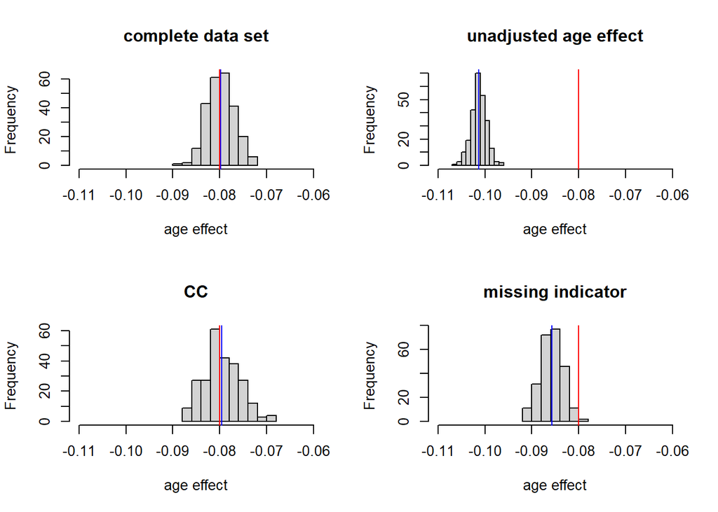

Note that the estimated age effect based on the complete case analysis results is unbiased (corresponds to the true coefficient on average), whereas the unadjusted analysis and missing indicator method provide biased estimates (due to missing confounder information).

The coverage for these methods was

```r
mean(nomiss.age.coverage) # nomimal
```

```
## [1] 0.948
```

```r
mean(unadj.age.coverage) # too low
```

```
## [1] 0
```

```r
mean(cc.age.coverage) # nominal
```

```
## [1] 0.952
```

```r
mean(mind.age.coverage) # too low
```

```
## [1] 0.312
```

### Randomized trial setting

Not we turn to the randomized trial setting with the aim of estimating a treatment effect. As above, the true age effect was -0.08; the true treatment effect was 1. The four histograms below show the true treatment effect (red line) and the average of the estimated effect across 250 runs (blue line):

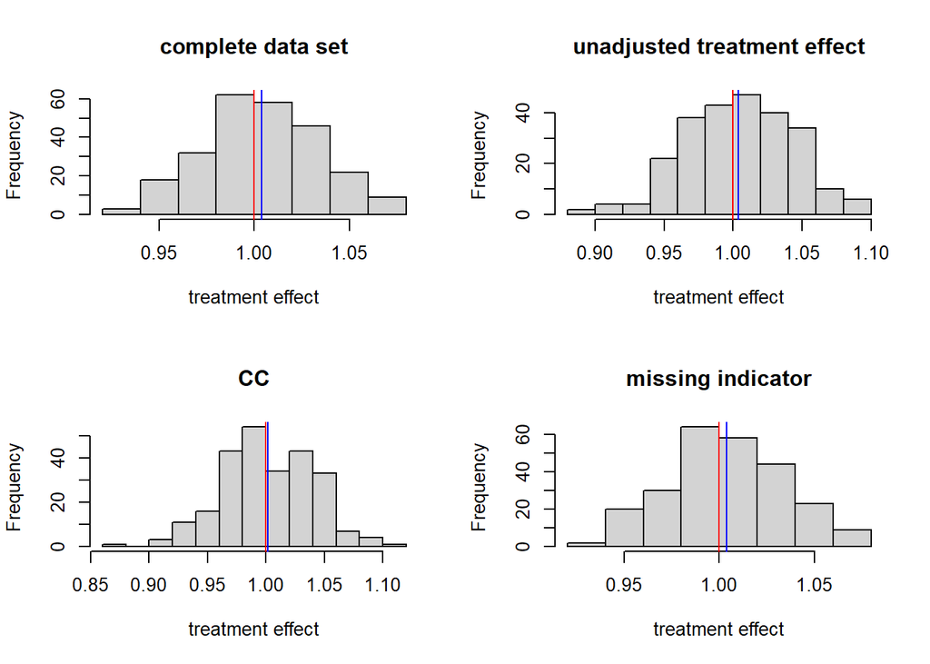

```r
par(mfrow=c(2,2))
hist(nomiss.trt.coef, main="complete data set", xlab="treatment effect"); abline(v=1, col="red"); abline(v=mean(nomiss.trt.coef), col="blue")
hist(unadj.trt.coef, main="unadjusted treatment effect", xlab="treatment effect"); abline(v=1, col="red"); abline(v=mean(unadj.trt.coef), col="blue")
hist(cc.trt.coef, main="CC", xlab="treatment effect"); abline(v=1, col="red"); abline(v=mean(cc.trt.coef), col="blue")
hist(mind.trt.coef, main="missing indicator", xlab="treatment effect"); abline(v=1, col="red"); abline(v=mean(mind.trt.coef), col="blue")
```

All are unbiased due to randomization! Coverage is also adequate:

```r
mean(nomiss.trt.coverage)
```

```
## [1] 0.964
```

```r
mean(unadj.trt.coverage)
```

```
## [1] 0.968
```

```r
mean(cc.trt.coverage)
```

```
## [1] 0.968
```

```r
mean(mind.trt.coverage)
```

```
## [1] 0.968
```

The benefit of the missing indicator method in this setting resides in the increased precision over both the unadjusted analysis (even though the baseline characteristics are not necessary to remove bias, they do improve precision) and the CCA (due to using all available cases).

```r
sd(nomiss.trt.coef)
```

```
## [1] 0.0304384
```

```r
sd(unadj.trt.coef)
```

```
## [1] 0.03934793
```

```r
sd(cc.trt.coef)
```

```
## [1] 0.0384195
```

```r
sd(mind.trt.coef)
```

```
## [1] 0.03044434
```

== End of practical ==